# 51job数据分析师职位分析

## 1.准备工作

### 1.1 载入库和初始化设置

```python
import numpy as np
import pandas as pd
import math
import matplotlib.pyplot as plt
import warnings
plt.rcParams['font.sans-serif'] = ['SimHei']
plt.rcParams['axes.unicode_minus'] = False
warnings.filterwarnings('ignore')

from pyecharts.charts import *
# 载入所有的图形元件
from pyecharts import options as opts
```

### 1.2 读取数据

```python
df1 = pd.read_excel('data/51joball.xlsx')
# 读取指定文件位置的工作簿第一个工作表，返回一个DataFrame
```

```python
df1.head()
```

|  | 职位 | 公司 | 薪酬 | 地点 | 工作经验 | 学历 | 福利 | 职位信息 | 公司性质 | 公司规模 | 行业 |
| --- | --- | --- | --- | --- | --- | --- | --- | --- | --- | --- | --- |
| 0 | 数据分析师(渠道/流量分析方向) | 阅文集团 | 2-3万/月 | 上海-浦东新区 | 5-7年经验 | 本科 | 五险一金/补充医疗保险/补充公积金/弹性工作/交通补贴/餐饮补贴/年终奖金/绩效奖金/定期体... | 职位信息\n \n \n 工作职责:承接业务需求，进行常规和专项数... | 上市公司 | 1000-5000人 | 互联网/电子商务 |
| 1 | 数据分析师 | 携程旅游信息技术（上海）有限公司 | 6-8千/月 | 上海-长宁区 | 无工作经验 | 本科 | 做五休二/五险一金/绩效奖金/全勤奖/节日福利/专业培训/餐饮补贴/定期体检/ | 职位信息\n \n \n 岗位职责：1、支持各种常规或临时数据分析... | 外资（欧美） | 500-1000人 | 酒店/旅游,互联网/电子商务 |
| 2 | 数据分析师（中国制造网） | 焦点科技股份有限公司 | 1-1.5万/月 | 南京 | 3-4年经验 | 本科 | 免费班车/一日三餐/员工宿舍/员工旅游/五险一金/年终奖金/绩效奖金/定期体检/专业培训/ | 职位信息\n \n \n 业务介绍：中国制造网（Made-in-C... | 上市公司 | 1000-5000人 | 互联网/电子商务,计算机软件 |
| 3 | 急聘数据分析师助理（底薪6K起） | 广州市大睿杭实业投资有限公司 | 6-8千/月 | 广州-天河区 | 无工作经验 | 大专 | 五险一金/专业培训/员工旅游/出国机会/绩效奖金/年终奖金/股票期权/弹性工作/周末双休/ | 职位信息\n \n \n 岗位职责：1、主要协助分析师工作，包括数... | 民营公司 | 50-150人 | 金融/投资/证券 |
| 4 | 数据分析师（急聘） | 广州中赢实业投资有限公司 | 0.8-1万/月 | 广州-天河区 | 1年经验 | 大专 | 五险一金/员工旅游/年终奖金/出国机会/专业培训/ | 职位信息\n \n \n 职位职责：1、收集和分析客户信息、关注客... | 外资（非欧美） | 500-1000人 | 金融/投资/证券 |

### 1.3 观察数据集的基本情况

```python
df1.info()
# 数据集的整体情况以及列的数据类型和缺失
```

```
<class 'pandas.core.frame.DataFrame'>
RangeIndex: 9553 entries, 0 to 9552
Data columns (total 11 columns):
 #   Column  Non-Null Count  Dtype
---  ------  --------------  -----
 0   职位      9374 non-null   object
 1   公司      9378 non-null   object
 2   薪酬      9102 non-null   object
 3   地点      9378 non-null   object
 4   工作经验    9378 non-null   object
 5   学历      9378 non-null   object
 6   福利      7706 non-null   object
 7   职位信息    9420 non-null   object
 8   公司性质    9418 non-null   object
 9   公司规模    9238 non-null   object
 10  行业      9362 non-null   object
dtypes: object(11)
memory usage: 821.1+ KB
```

从info的信息可以看出，数据集的每个字段中，都存在着或多或少的缺失情况，对缺失值的处理应当优先考虑

```python
df1.describe()
# 描述性统计分析
```

|  | 职位 | 公司 | 薪酬 | 地点 | 工作经验 | 学历 | 福利 | 职位信息 | 公司性质 | 公司规模 | 行业 |
| --- | --- | --- | --- | --- | --- | --- | --- | --- | --- | --- | --- |
| count | 9374 | 9378 | 9102 | 9378 | 9378 | 9378 | 7706 | 9420 | 9418 | 9238 | 9362 |
| unique | 4669 | 4330 | 374 | 386 | 7 | 9 | 4506 | 8032 | 11 | 7 | 645 |
| top | 数据分析师 | 广州天予信息科技有限公司 | 6-8千/月 | 广州-天河区 | 无工作经验 | 本科 | 五险一金/员工旅游/绩效奖金/弹性工作/定期体检/出国机会/专业培训/补充公积金/通讯补贴/ | 职位信息\n \n \n 一、岗位要求：1、对金融经济知识感兴趣，... | 民营公司 | 150-500人 | 金融/投资/证券 |
| freq | 1328 | 224 | 1272 | 1251 | 5058 | 3937 | 79 | 62 | 5951 | 2412 | 946 |

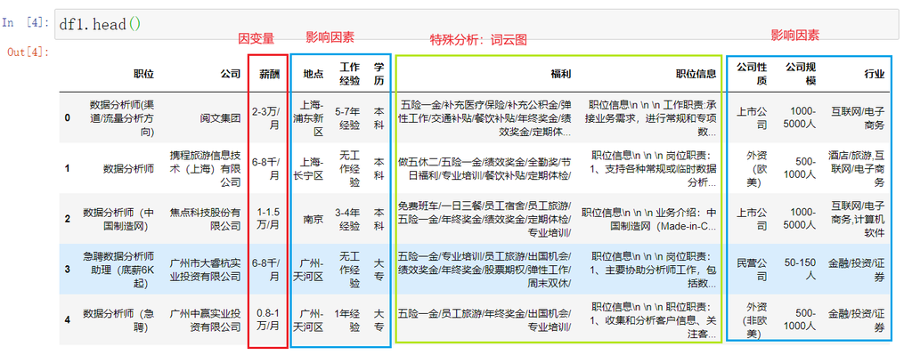

分析目标：  
1.分析各种影响因素对薪酬的影响  
2.观察福利待遇的情况（词云图）及技术名词分布情况（词云图）

## 2.数据清洗

### 2.1 对薪酬进行清洗

(1)删除薪酬中的缺失值

```python
# 原则：尽量不要在原始数据集上操作
df2 = df1.dropna(subset=['薪酬'])
```

```python
df2.info()
```

```
<class 'pandas.core.frame.DataFrame'>
Int64Index: 9102 entries, 0 to 9551
Data columns (total 11 columns):
 #   Column  Non-Null Count  Dtype
---  ------  --------------  -----
 0   职位      9099 non-null   object
 1   公司      9102 non-null   object
 2   薪酬      9102 non-null   object
 3   地点      9102 non-null   object
 4   工作经验    9102 non-null   object
 5   学历      9102 non-null   object
 6   福利      7655 non-null   object
 7   职位信息    9102 non-null   object
 8   公司性质    9100 non-null   object
 9   公司规模    9037 non-null   object
 10  行业      9093 non-null   object
dtypes: object(11)
memory usage: 853.3+ KB
```

```python
df2.薪酬.head(40)
```

```
0         2-3万/月
1         6-8千/月
2       1-1.5万/月
3         6-8千/月
4       0.8-1万/月
5         6-8千/月
6     0.8-1.6万/月
7         6-8千/月
8         5-8千/月
9       0.8-1万/月
10      1.5-2万/月
11        2-3万/月
12        6-8千/月
13        6-8千/月
14      4.5-6千/月
```

[output cut: 26 more lines]

(2)对薪酬的单位做统一化处理：统一到千/月

```python
salary = df2['薪酬'][0]
```

```python
salary
```

```
'2-3万/月'
```

薪酬处理的思路：

```
1.先判断薪酬的单位是什么
2.获取薪酬的最低最高值
3.根据单位计算统一到千/月的最低最高值：比如万/月，那么原始数据都乘以10
```

```python
postion1 = salary.find('万/月')
postion1
# 返回的结果是查找的子串在被查找字符串中起始的索引位置
# 如果找不到，返回-1
```

```
3
```

```python
postion2 = salary.find('-')
postion2
```

```
1
```

```python
# 利用postion1和2提取并计算薪酬的最低最高值
buttom = float(salary[:postion2]) * 10
# 提取最低薪酬，转换为浮点数，再乘以10，得到以千/月为单位的最低薪酬
buttom
```

```
20.0
```

```python
top = float(salary[postion2+1:postion1]) * 10
# 用切片的方式提取从‘-’到单位‘万/月’之间的内容，就是最高薪酬，再根据单位进行换算
top
```

```
30.0
```

```python
# 函数的思路
'''
1.找出单位，要分成三种，千/月,万/月，万/年
2.找出分隔符
3.根据单位进行判断，不同的单位进行不同的处理
4.通过参数，对最高和最低薪酬进行分别返回
'''
def cut_salary(word,method):
    # word是薪酬对应的字符串,method是用来确定返回最低还是最高薪酬
    # top返回最高薪酬，bottom返回最低薪酬

    # 1.找出单位对应的索引位置
    pos1 = word.find('万/月')
    pos2 = word.find('万/年')
    pos3 = word.find('千/月')

    # 2.找出分隔符对应的索引位置
    pos4 = word.find('-')

    # 3.根据三种单位分别进行判断及计算
    if pos1 != -1 : # 说明找到了"万/月"的单位
        if pos4 != -1 : # 说明找到了分隔符
            bottom = float(word[:pos4]) * 10      # 针对万/月进行计算
            top = float(word[pos4+1:pos1]) * 10
    elif pos2 != -1 : # 说明找到了"万/年"的单位
        if pos4 != -1 :
            bottom = float(word[:pos4]) * 10 / 12   # 针对万/年进行计算
            top = float(word[pos4+1:pos2]) * 10 / 12
    elif pos3 != -1 :  # 找到了“千/月”的单位
        if pos4 != -1:
            bottom = float(word[:pos4])  # 千/月不用计算，提取出数字即可
            top = float(word[pos4+1:pos3])
    else:
        bottom = np.nan
        top = np.nan
    # 以上三种情况都不满足，将薪酬设置为空（一般是临时性或实习类工作），方便后续直接删除

    # 4.根据method参数返回对应的值
    if method == 'top':
        return top
    else:
        return bottom
```

```python
salary
```

```
'2-3万/月'
```

```python
cut_salary(salary,method='top')
```

```
30.0
```

```python
cut_salary(salary,method='bottom')
```

```
20.0
```

```python
cut_salary('18-36万/年',method='top')
```

```
30.0
```

```python
cut_salary('18-36万/年',method='bottom')
```

```
15.0
```

```python
cut_salary('1.8-2.4千/月',method='top')
```

```
2.4
```

```python
cut_salary('1.8-2.4千/月',method='bottom')
```

```
1.8
```

```python
cut_salary('300元/天',method='top')
```

```
nan
```

```python
df2['tops'] = df2.薪酬.apply(cut_salary,method = 'top')
# apply中method = 'top' 是以**kwarags形式传入的参数，是为cut_salary使用的
df2['bottoms'] = df2.薪酬.apply(cut_salary,method = 'bottom')
# 分别计算最高和最低薪酬，并写入到新的列中
```

```python
df2.head(50)
```

|  | 职位 | 公司 | 薪酬 | 地点 | 工作经验 | 学历 | 福利 | 职位信息 | 公司性质 | 公司规模 | 行业 | tops | bottoms |
| --- | --- | --- | --- | --- | --- | --- | --- | --- | --- | --- | --- | --- | --- |
| 0 | 数据分析师(渠道/流量分析方向) | 阅文集团 | 2-3万/月 | 上海-浦东新区 | 5-7年经验 | 本科 | 五险一金/补充医疗保险/补充公积金/弹性工作/交通补贴/餐饮补贴/年终奖金/绩效奖金/定期体... | 职位信息\n \n \n 工作职责:承接业务需求，进行常规和专项数... | 上市公司 | 1000-5000人 | 互联网/电子商务 | 30.000000 | 20.000000 |
| 1 | 数据分析师 | 携程旅游信息技术（上海）有限公司 | 6-8千/月 | 上海-长宁区 | 无工作经验 | 本科 | 做五休二/五险一金/绩效奖金/全勤奖/节日福利/专业培训/餐饮补贴/定期体检/ | 职位信息\n \n \n 岗位职责：1、支持各种常规或临时数据分析... | 外资（欧美） | 500-1000人 | 酒店/旅游,互联网/电子商务 | 8.000000 | 6.000000 |
| 2 | 数据分析师（中国制造网） | 焦点科技股份有限公司 | 1-1.5万/月 | 南京 | 3-4年经验 | 本科 | 免费班车/一日三餐/员工宿舍/员工旅游/五险一金/年终奖金/绩效奖金/定期体检/专业培训/ | 职位信息\n \n \n 业务介绍：中国制造网（Made-in-C... | 上市公司 | 1000-5000人 | 互联网/电子商务,计算机软件 | 15.000000 | 10.000000 |
| 3 | 急聘数据分析师助理（底薪6K起） | 广州市大睿杭实业投资有限公司 | 6-8千/月 | 广州-天河区 | 无工作经验 | 大专 | 五险一金/专业培训/员工旅游/出国机会/绩效奖金/年终奖金/股票期权/弹性工作/周末双休/ | 职位信息\n \n \n 岗位职责：1、主要协助分析师工作，包括数... | 民营公司 | 50-150人 | 金融/投资/证券 | 8.000000 | 6.000000 |
| 4 | 数据分析师（急聘） | 广州中赢实业投资有限公司 | 0.8-1万/月 | 广州-天河区 | 1年经验 | 大专 | 五险一金/员工旅游/年终奖金/出国机会/专业培训/ | 职位信息\n \n \n 职位职责：1、收集和分析客户信息、关注客... | 外资（非欧美） | 500-1000人 | 金融/投资/证券 | 10.000000 | 8.000000 |
| 5 | 数据分析师/技术员(奖金+提成+五险) | 广州万德信息咨询服务有限公司 | 6-8千/月 | 广州-天河区 | 无工作经验 | 高中 | 五险一金/补充医疗保险/补充公积金/员工旅游/出国机会/专业培训/绩效奖金/ | 职位信息\n \n \n 岗位要求：1、年满18周岁，能力优秀者即... | 合资 | 150-500人 | 金融/投资/证券 | 8.000000 | 6.000000 |
| 6 | Data Analyst/数据分析师 | 大连华钦软件技术有限公司 | 0.8-1.6万/月 | 成都-高新区 | 3-4年经验 | 本科 | NaN | 职位信息\n \n \n Data AnalystData Ana... | 民营公司 | NaN | 计算机软件 | 16.000000 | 8.000000 |
| 7 | 金融数据分析师（高底薪+五险一金） | 广州市大睿杭实业投资有限公司 | 6-8千/月 | 广州-天河区 | 无工作经验 | 高中 | 五险一金/员工旅游/专业培训/出国机会/绩效奖金/年终奖金/弹性工作/股票期权/ | 职位信息\n \n \n 岗位职责：1.定期整理交易数据，向上级领... | 民营公司 | 50-150人 | 金融/投资/证券 | 8.000000 | 6.000000 |
| 8 | 非销售数据分析师5-8K+双休五险 | 西安壬林商务信息咨询有限公司 | 5-8千/月 | 西安-雁塔区 | 无工作经验 | 无学历要求 | 五险一金/员工旅游/周末双休/不加班/早九晚五/带薪年假/节假日福利/专业培训/晋升空间大/... | 职位信息\n \n \n 岗位职责:1、搜集行业相关信息，为相关需... | 民营公司 | 500-1000人 | 金融/投资/证券,专业服务(咨询、人力资源、财会) | 8.000000 | 5.000000 |
| 9 | a（0经验可培养）金融数据分析师/助理 | 深圳市中创荣投资有限公司 | 0.8-1万/月 | 深圳-罗湖区 | 无工作经验 | 大专 | NaN | 职位信息\n \n \n 一、任职资格1、热爱金融行业，有强烈的意... | 民营公司 | 50-150人 | 金融/投资/证券 | 10.000000 | 8.000000 |
| 10 | 数据分析师(J11915) | 深圳依时货拉拉科技有限公司 | 1.5-2万/月 | 深圳-福田区 | 无工作经验 | 无学历要求 | 做五休二/周末双休/带薪年假/五险一金/绩效奖金/节日福利/专业培训/股票期权/ | 职位信息\n \n \n 工作职责:1、了解公司业务，建设数据指标... | 外资（非欧美） | 1000-5000人 | 互联网/电子商务 | 20.000000 | 15.000000 |
| 11 | 数据分析师（自然语言） | 兴业消费金融股份公司 | 2-3万/月 | 上海-浦东新区 | 2年经验 | 本科 | 五险一金/绩效奖金/专业培训/定期体检/通讯补贴/ | 职位信息\n \n \n 【职位描述】：参与/负责分词、命名实体识... | 国企 | 1000-5000人 | 金融/投资/证券 | 30.000000 | 20.000000 |
| 12 | 急聘数据分析师助理（底薪6K起） | 广州市大睿杭实业投资有限公司 | 6-8千/月 | 广州-天河区 | 无工作经验 | 高中 | 五险一金/定期体检/弹性工作/股票期权/年终奖金/周末双休/专业培训/员工旅游/出国机会/绩... | 职位信息\n \n \n 职位职责：1、收集和分析客户信息、关注客... | 民营公司 | 50-150人 | 金融/投资/证券 | 8.000000 | 6.000000 |
| 13 | 数据分析师（专业培训+周末双休） | 广州市大睿杭实业投资有限公司 | 6-8千/月 | 广州-天河区 | 无工作经验 | 高中 | 五险一金/年终奖金/弹性工作/定期体检/股票期权/绩效奖金/专业培训/员工旅游/周末双休/ | 职位信息\n \n \n 别看底薪高低，别担心未来迷茫，文本虽然不... | 民营公司 | 50-150人 | 金融/投资/证券 | 8.000000 | 6.000000 |
| 14 | 数据分析师 | 武汉房小白咨询管理有限公司 | 4.5-6千/月 | 武汉-汉阳区 | 无工作经验 | 无学历要求 | 五险一金/绩效奖金/入职协调住宿/通讯补贴/加班补贴/节日福利/ | 职位信息\n \n \n 1、要求掌握全面的业务知识和计算机应用能... | 民营公司 | 500-1000人 | 房地产 | 6.000000 | 4.500000 |
| 15 | 数据分析师 | 广州市原象信息科技有限公司北京分公司 | 0.7-1万/月 | 广州-海珠区 | 2年经验 | 本科 | 五险一金/补充医疗保险/补充公积金/员工旅游/餐饮补贴/专业培训/年终奖金/弹性工作/定期体检/ | 职位信息\n \n \n 数据分析师（内容营销方向）：工作职责：1... | 民营公司 | 150-500人 | 互联网/电子商务,广告 | 10.000000 | 7.000000 |
| 16 | 数据分析师 | 深圳智高点知识产权运营有限公司 | 3-4.5千/月 | 深圳-南山区 | 无工作经验 | 无学历要求 | NaN | 职位信息\n \n \n 工作内容：1、负责客户的知识产权需求分析... | 民营公司 | 50-150人 | 互联网/电子商务,专业服务(咨询、人力资源、财会) | 4.500000 | 3.000000 |
| 17 | 数据分析师 | 苏州南讯科技有限公司 | 5-8千/月 | 苏州-工业园区 | 无工作经验 | 大专 | 带薪年假/五险一金/绩效奖金/全勤奖/节日福利/交通补贴/餐饮补贴/ | 职位信息\n \n \n 工作内容：1、构建微信公众号运营数据分析... | 民营公司 | 50-150人 | 互联网/电子商务,影视/媒体/艺术/文化传播 | 8.000000 | 5.000000 |
| 18 | 数据分析师 | 广州快塑电子商务有限公司 | 0.8-1万/月 | 广州-天河区 | 3-4年经验 | 大专 | 周末双休/带薪年假/五险一金/绩效奖金/节日福利/专业培训/餐饮补贴/ | 职位信息\n \n \n 岗位职责：1、负责数据分析挖掘，构建各种... | 民营公司 | 150-500人 | 互联网/电子商务,石油/化工/矿产/地质 | 10.000000 | 8.000000 |
| 19 | 数据分析师 | 深圳市第一卫电子有限公司 | 1.2-2万/月 | 深圳-龙华新区 | 3-4年经验 | 本科 | 五险一金/员工旅游/年终奖金/绩效奖金/ | 职位信息\n \n \n 岗位职责：1、基于对公司业务的理解，负责... | 民营公司 | 500-1000人 | 互联网/电子商务 | 20.000000 | 12.000000 |
| 20 | BI - 资深数据分析师 | 深圳虾皮信息科技有限公司 | 1.5-2.5万/月 | 深圳-南山区 | 3-4年经验 | 本科 | 五险一金/补充医疗保险/餐饮补贴/交通补贴/专业培训/出国机会/年终奖金/定期体检/ | 职位信息\n \n \n 【岗位描述】负责中国大陆地区卖家管理业务... | 上市公司 | 5000-10000人 | 互联网/电子商务 | 25.000000 | 15.000000 |
| 21 | 数据分析师 | 瑞银企业管理（中国）有限公司 | 0.8-1万/月 | 无锡 | 无工作经验 | 无学历要求 | NaN | 职位信息\n \n \n *Your role : ... | 外资（欧美） | 500-1000人 | 银行,金融/投资/证券 | 10.000000 | 8.000000 |
| 22 | 数据分析师（双休+提成+五险） | 广州万德信息咨询服务有限公司 | 4.5-6千/月 | 广州-天河区 | 无工作经验 | 高中 | 五险一金/专业培训/弹性工作/绩效奖金/员工旅游/ | 职位信息\n \n \n 1、主要协助分析师工作，包括数据整理、分... | 合资 | 150-500人 | 金融/投资/证券 | 6.000000 | 4.500000 |
| 23 | 数据分析师 | 江苏牛观数据科技有限责任公司 | 0.8-1万/月 | 南京-建邺区 | 3-4年经验 | 大专 | 五险一金/交通补贴/股票期权/餐饮补贴/ | 职位信息\n \n \n 数据分析工程师岗位职责1、负责不同来源数... | 民营公司 | 少于50人 | 互联网/电子商务,计算机软件 | 10.000000 | 8.000000 |
| 24 | 数据分析师（电商） | 上海联蔚数据科技有限公司 | 6-8千/月 | 上海-黄浦区 | 无工作经验 | 无学历要求 | NaN | 职位信息\n \n \n 1、对品牌电商表现的进行分析，交付数据分... | 外资（欧美） | 500-1000人 | 互联网/电子商务,计算机服务(系统、数据服务、维修) | 8.000000 | 6.000000 |
| 25 | 数据分析师 | 上海雨尚服饰有限公司 | 300元/天 | 杭州-上城区 | 3-4年经验 | 大专 | NaN | 职位信息\n \n \n 岗位职责1、负责统计业务部门的系统数据，... | 民营公司 | 少于50人 | 服装/纺织/皮革 | NaN | NaN |
| 26 | 商业数据分析师 | 天聚地合（苏州）数据股份有限公司 | 0.5-1万/月 | 苏州-工业园区 | 无工作经验 | 无学历要求 | 五险一金/绩效奖金/年终奖金/员工旅游/弹性工作/ | 职位信息\n \n \n 【岗位职责】： 1. 以数据为驱动，负责... | 民营公司 | 50-150人 | 计算机软件,互联网/电子商务 | 10.000000 | 5.000000 |
| 27 | 数据分析师（政务服务+双休） | 广东集成数据有限公司 | 4-8.5千/月 | 佛山-禅城区 | 无工作经验 | 本科 | 五险一金/餐饮补贴/通讯补贴/定期体检/绩效奖金/商业保险/带薪年假/ | 职位信息\n \n \n 岗位职责：1、参与公司数据项目的前期调研... | 民营公司 | 50-150人 | 计算机服务(系统、数据服务、维修) | 8.500000 | 4.000000 |
| 28 | 投资数据分析师(可应届+朝九晚五) | 广州天予信息科技有限公司 | 8-10万/年 | 广州-天河区 | 无工作经验 | 本科 | 五险一金/免费班车/员工旅游/专业培训/出国机会/绩效奖金/年终奖金/ | 职位信息\n \n \n 岗位要求： 1、对金融经济知识感兴趣，... | 民营公司 | 500-1000人 | 金融/投资/证券,互联网/电子商务 | 8.333333 | 6.666667 |
| 29 | 投资数据分析师（双休+朝九晚五） | 广州天予信息科技有限公司 | 8-10万/年 | 广州-天河区 | 无工作经验 | 本科 | 五险一金/补充医疗保险/补充公积金/员工旅游/出国机会/绩效奖金/定期体检/专业培训/ | 职位信息\n \n \n 岗位要求：1、对金融经济知识感兴趣，希望... | 民营公司 | 500-1000人 | 金融/投资/证券,互联网/电子商务 | 8.333333 | 6.666667 |
| 30 | 财务数据分析师 | 震坤行工业超市（上海）有限公司 | 1.5-2万/月 | 上海 | 5-7年经验 | 本科 | 五险一金/补充医疗保险/员工旅游/交通补贴/绩效奖金/定期体检/餐饮补贴/通讯补贴/ | 职位信息\n \n \n 岗位职责： 对公司各项经营指标进行分析... | 民营公司 | 500-1000人 | 互联网/电子商务 | 20.000000 | 15.000000 |
| 31 | 商品数据分析师 | 广州熙彬贸易有限公司 | 0.6-1万/月 | 广州-白云区 | 2年经验 | 大专 | 五险一金/员工旅游/弹性工作/出国机会/专业培训/绩效奖金/年终奖金/带薪年假/节假日福利/ | 职位信息\n \n \n 1，建立数据报表，追踪每个月份、每周、每... | 民营公司 | 500-1000人 | 批发/零售,家具/家电/玩具/礼品 | 10.000000 | 6.000000 |
| 32 | 投资数据分析师（双休+专业培训） | 广州天予信息科技有限公司 | 8-10万/年 | 广州-天河区 | 无工作经验 | 本科 | 五险一金/补充医疗保险/补充公积金/员工旅游/出国机会/专业培训/绩效奖金/年终奖金/弹性工... | 职位信息\n \n \n 岗位要求：1、对金融经济知识感兴趣，希望... | 民营公司 | 500-1000人 | 金融/投资/证券,互联网/电子商务 | 8.333333 | 6.666667 |
| 33 | 金融数据分析师（福利+奖金） | 广州天予信息科技有限公司 | 8-10万/年 | 广州-天河区 | 无工作经验 | 本科 | 五险一金/补充公积金/补充医疗保险/免费班车/员工旅游/绩效奖金/年终奖金/弹性工作/定期体... | 职位信息\n \n \n 一、岗位要求： 1、对金融经济... | 民营公司 | 500-1000人 | 金融/投资/证券,互联网/电子商务 | 8.333333 | 6.666667 |
| 34 | 数据分析师 | 广州迪柯尼服饰股份有限公司 | 1.5-2万/月 | 广州-天河区 | 5-7年经验 | 本科 | 五险一金/交通补贴/年终奖金/绩效奖金/专业培训/餐饮补贴/定期体检/ | 职位信息\n \n \n 1.负责理解商业需求，运用统计建模，数据... | 民营公司 | 1000-5000人 | 服装/纺织/皮革,批发/零售 | 20.000000 | 15.000000 |
| 35 | 大数据分析师（厦门市） | 厦门市巨龙信息科技有限公司 | 0.7-1.4万/月 | 厦门 | 1年经验 | 大专 | 五险一金/补充医疗保险/免费班车/员工旅游/绩效奖金/定期体检/专业培训/ | 职位信息\n \n \n 岗位职责：1、实现对业务数据分析模型的研... | 民营公司 | 500-1000人 | 计算机软件 | 14.000000 | 7.000000 |
| 36 | Java数据分析师 五险+双休 | 正方软件科技 | 4.5-6千/月 | 合肥 | 无工作经验 | 大专 | 五险一金/交通补贴/年终奖金/绩效奖金/餐饮补贴/弹性工作/ | 职位信息\n \n \n 一、任职要求1、本、专科学历以上的应届、... | 民营公司 | 150-500人 | 计算机软件 | 6.000000 | 4.500000 |
| 37 | 投资数据分析师（双休+朝九晚五） | 广州天予信息科技有限公司 | 8-10万/年 | 广州-天河区 | 无工作经验 | 本科 | 补充医疗保险/五险一金/补充公积金/员工旅游/专业培训/绩效奖金/年终奖金/弹性工作/股票期权/ | 职位信息\n \n \n 岗位要求： 1、对金融经济知识... | 民营公司 | 500-1000人 | 金融/投资/证券,互联网/电子商务 | 8.333333 | 6.666667 |
| 38 | 数据分析师 (MJ006394) | 达内时代科技集团有限公司 | 1-2万/月 | 北京-海淀区 | 2年经验 | 本科 | 五险一金/专业培训/绩效奖金/股票期权/午餐补助/员工旅游/ | 职位信息\n \n \n 岗位职责： 1、负责数据分析挖掘，构建各... | 上市公司 | 5000-10000人 | 教育/培训/院校 | 20.000000 | 10.000000 |
| 39 | 数据分析师 | 广州吉尔雅商贸有限公司 | 6-8千/月 | 广州 | 无工作经验 | 无学历要求 | 节日福利/带薪年假/加班补贴/五险/ | 职位信息\n \n \n 岗位职责 1、负责包类日常商品管理... | 民营公司 | 50-150人 | 贸易/进出口 | 8.000000 | 6.000000 |
| 40 | 电商数据分析师 | 深圳市雷诺表业有限公司 | 0.8-1.2万/月 | 深圳 | 2年经验 | 本科 | 五险一金/弹性工作/员工旅游/周末双休/包吃包住/ | 职位信息\n \n \n 职位信息1. 负责电商运营数据统计及数据... | 民营公司 | 1000-5000人 | 奢侈品/收藏品/工艺品/珠宝,家具/家电/玩具/礼品 | 12.000000 | 8.000000 |
| 41 | 数据分析师 | 深圳市博爱投资管理有限公司 | 6-8千/月 | 深圳-罗湖区 | 1年经验 | 大专 | 五险一金/绩效奖金/专业培训/定期体检/员工旅游/餐饮补贴/ | 职位信息\n \n \n 1、熟悉数据处理加工等办公软件，如EXC... | 民营公司 | 1000-5000人 | 医疗/护理/卫生 | 8.000000 | 6.000000 |
| 42 | 亚马逊运营专员/数据分析师（五险一金+双休） | 广东一鸣信息科技有限公司 | 6-8千/月 | 东莞-南城区 | 2年经验 | 大专 | 周末双休/带薪年假/五险一金/绩效奖金/节日福利/专业培训/ | 职位信息\n \n \n 工作职责：1. 调研亚马逊、阿里巴巴等平... | 民营公司 | 少于50人 | 互联网/电子商务,贸易/进出口 | 8.000000 | 6.000000 |
| 43 | 数据分析师 | 深圳市房比房网络科技有限公司 | 1-1.5万/月 | 深圳-龙华新区 | 2年经验 | 大专 | NaN | 职位信息\n \n \n 数据分析师（1名）岗位职责:1、负责数据... | 民营公司 | 50-150人 | 互联网/电子商务,电子技术/半导体/集成电路 | 15.000000 | 10.000000 |
| 44 | 数据挖掘工程师（数据分析师） (职位编号：BW-001) | 广州市博汇数码科技有限公司 | 0.8-1.5万/月 | 广州 | 3-4年经验 | 本科 | 五险一金/餐饮补贴/年终奖金/弹性工作/定期体检/ | 职位信息\n \n \n 岗位职责：1. 参与数据挖掘项目，通过数... | 民营公司 | 少于50人 | 计算机软件,通信/电信运营、增值服务 | 15.000000 | 8.000000 |
| 45 | 不销售/不加班/双休（数据分析师/交易员） | 广州华臻信息咨询服务有限公司 | 6-8千/月 | 广州-天河区 | 无工作经验 | 高中 | 五险一金/员工旅游/出国机会/专业培训/股票期权/弹性工作/周末双休/ | 职位信息\n \n \n 一、【公司承诺】1.不做销售，不拉客户，... | 民营公司 | 150-500人 | 金融/投资/证券 | 8.000000 | 6.000000 |
| 46 | 数据分析师 | 重庆西西弗文化传播有限公司 | 5-7千/月 | 重庆-渝中区 | 无工作经验 | 本科 | 五险/员工旅游/专业培训/绩效奖金/ | 职位信息\n \n \n 【岗位职责】1.从不同数据平台口径收集基... | 民营公司 | 1000-5000人 | 影视/媒体/艺术/文化传播,批发/零售 | 7.000000 | 5.000000 |
| 47 | 数据分析师 | 上海宏路数据技术股份有限公司 | 0.9-1.8万/月 | 上海-虹口区 | 2年经验 | 本科 | 五险一金/补充医疗保险/员工旅游/定期体检/绩效奖金/年终奖金/ | 职位信息\n \n \n 岗位职责：1.负责金融、汽车、新零售行业... | 上市公司 | 150-500人 | 互联网/电子商务,计算机服务(系统、数据服务、维修) | 18.000000 | 9.000000 |
| 48 | 数据分析师 (职位编号：LilithGames000708) | 上海莉莉丝科技股份有限公司 | 1.2-2.4万/月 | 上海 | 1年经验 | 本科 | 五险一金/年终奖金/弹性工作/员工旅游/定期体检/ | 职位信息\n \n \n 岗位职责:1) 帮助游戏业务的各个环节(... | 民营公司 | 150-500人 | 网络游戏,互联网/电子商务 | 24.000000 | 12.000000 |
| 49 | 数据分析师 (职位编号：TOPCHANCE000691) | 广州市广德昌科技有限公司 | 4.5-7千/月 | 广州 | 无工作经验 | 大专 | 五险一金/员工旅游/专业培训/绩效奖金/弹性工作/员工体检/商业保险/高温补贴/ | 职位信息\n \n \n 岗位职责:1.挖掘管理层和业务部门数据需... | 民营公司 | 150-500人 | 医疗设备/器械,医疗/护理/卫生 | 7.000000 | 4.500000 |

```python
df2.info()
```

```
<class 'pandas.core.frame.DataFrame'>
Int64Index: 9102 entries, 0 to 9551
Data columns (total 13 columns):
 #   Column   Non-Null Count  Dtype
---  ------   --------------  -----
 0   职位       9099 non-null   object
 1   公司       9102 non-null   object
 2   薪酬       9102 non-null   object
 3   地点       9102 non-null   object
 4   工作经验     9102 non-null   object
 5   学历       9102 non-null   object
 6   福利       7655 non-null   object
 7   职位信息     9102 non-null   object
 8   公司性质     9100 non-null   object
 9   公司规模     9037 non-null   object
 10  行业       9093 non-null   object
 11  tops     8993 non-null   float64
 12  bottoms  8993 non-null   float64
dtypes: float64(2), object(11)
memory usage: 1.3+ MB
```

薪酬数据中bottoms和tops中缺失的数据部分就是不属于三种常见单位的薪酬，一般认为是临时或实习类工作，这里直接用dropna删除

```python
df3 = df2.dropna(subset=['tops'])
```

```python
df3.info()
```

```
<class 'pandas.core.frame.DataFrame'>
Int64Index: 8993 entries, 0 to 9551
Data columns (total 13 columns):
 #   Column   Non-Null Count  Dtype
---  ------   --------------  -----
 0   职位       8990 non-null   object
 1   公司       8993 non-null   object
 2   薪酬       8993 non-null   object
 3   地点       8993 non-null   object
 4   工作经验     8993 non-null   object
 5   学历       8993 non-null   object
 6   福利       7581 non-null   object
 7   职位信息     8993 non-null   object
 8   公司性质     8991 non-null   object
 9   公司规模     8928 non-null   object
 10  行业       8984 non-null   object
 11  tops     8993 non-null   float64
 12  bottoms  8993 non-null   float64
dtypes: float64(2), object(11)
memory usage: 983.6+ KB
```

(3)计算平均薪酬和对数平均薪酬

```python
df3['avgsalary'] = df3.apply(lambda x:(x.tops + x.bottoms) / 2, axis=1)
# 构建一个新的列，因为操作涉及多列，所以在DataFrame上进行apply,另外要注意axis的轴向
```

```python
df3.head()
```

|  | 职位 | 公司 | 薪酬 | 地点 | 工作经验 | 学历 | 福利 | 职位信息 | 公司性质 | 公司规模 | 行业 | tops | bottoms | avgsalary |
| --- | --- | --- | --- | --- | --- | --- | --- | --- | --- | --- | --- | --- | --- | --- |
| 0 | 数据分析师(渠道/流量分析方向) | 阅文集团 | 2-3万/月 | 上海-浦东新区 | 5-7年经验 | 本科 | 五险一金/补充医疗保险/补充公积金/弹性工作/交通补贴/餐饮补贴/年终奖金/绩效奖金/定期体... | 职位信息\n \n \n 工作职责:承接业务需求，进行常规和专项数... | 上市公司 | 1000-5000人 | 互联网/电子商务 | 30.0 | 20.0 | 25.0 |
| 1 | 数据分析师 | 携程旅游信息技术（上海）有限公司 | 6-8千/月 | 上海-长宁区 | 无工作经验 | 本科 | 做五休二/五险一金/绩效奖金/全勤奖/节日福利/专业培训/餐饮补贴/定期体检/ | 职位信息\n \n \n 岗位职责：1、支持各种常规或临时数据分析... | 外资（欧美） | 500-1000人 | 酒店/旅游,互联网/电子商务 | 8.0 | 6.0 | 7.0 |
| 2 | 数据分析师（中国制造网） | 焦点科技股份有限公司 | 1-1.5万/月 | 南京 | 3-4年经验 | 本科 | 免费班车/一日三餐/员工宿舍/员工旅游/五险一金/年终奖金/绩效奖金/定期体检/专业培训/ | 职位信息\n \n \n 业务介绍：中国制造网（Made-in-C... | 上市公司 | 1000-5000人 | 互联网/电子商务,计算机软件 | 15.0 | 10.0 | 12.5 |
| 3 | 急聘数据分析师助理（底薪6K起） | 广州市大睿杭实业投资有限公司 | 6-8千/月 | 广州-天河区 | 无工作经验 | 大专 | 五险一金/专业培训/员工旅游/出国机会/绩效奖金/年终奖金/股票期权/弹性工作/周末双休/ | 职位信息\n \n \n 岗位职责：1、主要协助分析师工作，包括数... | 民营公司 | 50-150人 | 金融/投资/证券 | 8.0 | 6.0 | 7.0 |
| 4 | 数据分析师（急聘） | 广州中赢实业投资有限公司 | 0.8-1万/月 | 广州-天河区 | 1年经验 | 大专 | 五险一金/员工旅游/年终奖金/出国机会/专业培训/ | 职位信息\n \n \n 职位职责：1、收集和分析客户信息、关注客... | 外资（非欧美） | 500-1000人 | 金融/投资/证券 | 10.0 | 8.0 | 9.0 |

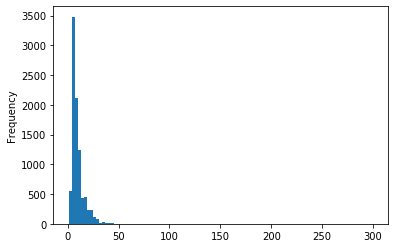

```python
df3.avgsalary.plot(kind='hist',bins=100)
# 从直方图可以看出，平均薪酬的分布呈现严重的右偏形态（偏大的异常值多），
# 因此要对其做一个对数化转换，以便更接近正态分布，方便进行后续的建模分析
```

```python
df3['lnsalary'] = df3.apply(lambda x : math.log(x.avgsalary),axis=1)
```

```python
df3.head()
```

|  | 职位 | 公司 | 薪酬 | 地点 | 工作经验 | 学历 | 福利 | 职位信息 | 公司性质 | 公司规模 | 行业 | tops | bottoms | avgsalary | lnsalary |
| --- | --- | --- | --- | --- | --- | --- | --- | --- | --- | --- | --- | --- | --- | --- | --- |
| 0 | 数据分析师(渠道/流量分析方向) | 阅文集团 | 2-3万/月 | 上海-浦东新区 | 5-7年经验 | 本科 | 五险一金/补充医疗保险/补充公积金/弹性工作/交通补贴/餐饮补贴/年终奖金/绩效奖金/定期体... | 职位信息\n \n \n 工作职责:承接业务需求，进行常规和专项数... | 上市公司 | 1000-5000人 | 互联网/电子商务 | 30.0 | 20.0 | 25.0 | 3.218876 |
| 1 | 数据分析师 | 携程旅游信息技术（上海）有限公司 | 6-8千/月 | 上海-长宁区 | 无工作经验 | 本科 | 做五休二/五险一金/绩效奖金/全勤奖/节日福利/专业培训/餐饮补贴/定期体检/ | 职位信息\n \n \n 岗位职责：1、支持各种常规或临时数据分析... | 外资（欧美） | 500-1000人 | 酒店/旅游,互联网/电子商务 | 8.0 | 6.0 | 7.0 | 1.945910 |
| 2 | 数据分析师（中国制造网） | 焦点科技股份有限公司 | 1-1.5万/月 | 南京 | 3-4年经验 | 本科 | 免费班车/一日三餐/员工宿舍/员工旅游/五险一金/年终奖金/绩效奖金/定期体检/专业培训/ | 职位信息\n \n \n 业务介绍：中国制造网（Made-in-C... | 上市公司 | 1000-5000人 | 互联网/电子商务,计算机软件 | 15.0 | 10.0 | 12.5 | 2.525729 |
| 3 | 急聘数据分析师助理（底薪6K起） | 广州市大睿杭实业投资有限公司 | 6-8千/月 | 广州-天河区 | 无工作经验 | 大专 | 五险一金/专业培训/员工旅游/出国机会/绩效奖金/年终奖金/股票期权/弹性工作/周末双休/ | 职位信息\n \n \n 岗位职责：1、主要协助分析师工作，包括数... | 民营公司 | 50-150人 | 金融/投资/证券 | 8.0 | 6.0 | 7.0 | 1.945910 |
| 4 | 数据分析师（急聘） | 广州中赢实业投资有限公司 | 0.8-1万/月 | 广州-天河区 | 1年经验 | 大专 | 五险一金/员工旅游/年终奖金/出国机会/专业培训/ | 职位信息\n \n \n 职位职责：1、收集和分析客户信息、关注客... | 外资（非欧美） | 500-1000人 | 金融/投资/证券 | 10.0 | 8.0 | 9.0 | 2.197225 |

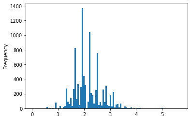

```python
df3.lnsalary.plot(kind='hist',bins=100)
```

```python
# 养成随时保存中间文件的习惯
# 一般情况下，建议用csv格式，文件大小和操作性能都优于xlsx
df3.to_csv('data/51salary.csv')
```

**把列名称改为英文，方便后续编码操作，同时做一个筛选，只保留后续分析需要的列**

```python
df4 = df3.rename(
    columns = {
        '地点':'location',
        '工作经验':'exp',
        '学历':'edu',
        '公司性质':'type',
        '公司规模':'scale',
        '行业':'industry'
    }
)
```

```python
df4.head(1)
```

|  | 职位 | 公司 | 薪酬 | location | exp | edu | 福利 | 职位信息 | type | scale | industry | tops | bottoms | avgsalary | lnsalary |
| --- | --- | --- | --- | --- | --- | --- | --- | --- | --- | --- | --- | --- | --- | --- | --- |
| 0 | 数据分析师(渠道/流量分析方向) | 阅文集团 | 2-3万/月 | 上海-浦东新区 | 5-7年经验 | 本科 | 五险一金/补充医疗保险/补充公积金/弹性工作/交通补贴/餐饮补贴/年终奖金/绩效奖金/定期体... | 职位信息\n \n \n 工作职责:承接业务需求，进行常规和专项数... | 上市公司 | 1000-5000人 | 互联网/电子商务 | 30.0 | 20.0 | 25.0 | 3.218876 |

**提取需要的列**

```python
df5 = df4[['location','exp','edu','type','scale','industry','avgsalary','lnsalary']]
```

```python
df5.head()
```

|  | location | exp | edu | type | scale | industry | avgsalary | lnsalary |
| --- | --- | --- | --- | --- | --- | --- | --- | --- |
| 0 | 上海-浦东新区 | 5-7年经验 | 本科 | 上市公司 | 1000-5000人 | 互联网/电子商务 | 25.0 | 3.218876 |
| 1 | 上海-长宁区 | 无工作经验 | 本科 | 外资（欧美） | 500-1000人 | 酒店/旅游,互联网/电子商务 | 7.0 | 1.945910 |
| 2 | 南京 | 3-4年经验 | 本科 | 上市公司 | 1000-5000人 | 互联网/电子商务,计算机软件 | 12.5 | 2.525729 |
| 3 | 广州-天河区 | 无工作经验 | 大专 | 民营公司 | 50-150人 | 金融/投资/证券 | 7.0 | 1.945910 |
| 4 | 广州-天河区 | 1年经验 | 大专 | 外资（非欧美） | 500-1000人 | 金融/投资/证券 | 9.0 | 2.197225 |

```python
df5.to_csv('data/51jobclean1.csv')
```

### 2.2 对工作地点进行清洗

(1)对location进行分列，获取城市名称  
因为区划会影响到工作地点的类别数量，不方便后续处理，所以要提取出城市

```python
df5.location[0]
```

```
'上海-浦东新区'
```

```python
df5.location[0].split('-')[0]
```

```
'上海'
```

```python
df5['city'] = df5.apply(lambda x:x.location.split('-')[0], axis=1)
# 提取location中的第一部分，返回城市名称，并构建一个新的列
```

```python
df5.head()
```

|  | location | exp | edu | type | scale | industry | avgsalary | lnsalary | city |
| --- | --- | --- | --- | --- | --- | --- | --- | --- | --- |
| 0 | 上海-浦东新区 | 5-7年经验 | 本科 | 上市公司 | 1000-5000人 | 互联网/电子商务 | 25.0 | 3.218876 | 上海 |
| 1 | 上海-长宁区 | 无工作经验 | 本科 | 外资（欧美） | 500-1000人 | 酒店/旅游,互联网/电子商务 | 7.0 | 1.945910 | 上海 |
| 2 | 南京 | 3-4年经验 | 本科 | 上市公司 | 1000-5000人 | 互联网/电子商务,计算机软件 | 12.5 | 2.525729 | 南京 |
| 3 | 广州-天河区 | 无工作经验 | 大专 | 民营公司 | 50-150人 | 金融/投资/证券 | 7.0 | 1.945910 | 广州 |
| 4 | 广州-天河区 | 1年经验 | 大专 | 外资（非欧美） | 500-1000人 | 金融/投资/证券 | 9.0 | 2.197225 | 广州 |

删除location列

```python
df_city = df5.drop('location',axis=1)
```

```python
df_city.head()
```

|  | exp | edu | type | scale | industry | avgsalary | lnsalary | city |
| --- | --- | --- | --- | --- | --- | --- | --- | --- |
| 0 | 5-7年经验 | 本科 | 上市公司 | 1000-5000人 | 互联网/电子商务 | 25.0 | 3.218876 | 上海 |
| 1 | 无工作经验 | 本科 | 外资（欧美） | 500-1000人 | 酒店/旅游,互联网/电子商务 | 7.0 | 1.945910 | 上海 |
| 2 | 3-4年经验 | 本科 | 上市公司 | 1000-5000人 | 互联网/电子商务,计算机软件 | 12.5 | 2.525729 | 南京 |
| 3 | 无工作经验 | 大专 | 民营公司 | 50-150人 | 金融/投资/证券 | 7.0 | 1.945910 | 广州 |
| 4 | 1年经验 | 大专 | 外资（非欧美） | 500-1000人 | 金融/投资/证券 | 9.0 | 2.197225 | 广州 |

```python
df_city.describe(include='all')
```

|  | exp | edu | type | scale | industry | avgsalary | lnsalary | city |
| --- | --- | --- | --- | --- | --- | --- | --- | --- |
| count | 8993 | 8993 | 8991 | 8928 | 8984 | 8993.000000 | 8993.000000 | 8993 |
| unique | 7 | 9 | 10 | 7 | 640 | NaN | NaN | 150 |
| top | 无工作经验 | 本科 | 民营公司 | 150-500人 | 金融/投资/证券 | NaN | NaN | 广州 |
| freq | 4798 | 3672 | 5784 | 2374 | 932 | NaN | NaN | 1909 |
| mean | NaN | NaN | NaN | NaN | NaN | 9.919919 | 2.144584 | NaN |
| std | NaN | NaN | NaN | NaN | NaN | 7.388466 | 0.518397 | NaN |
| min | NaN | NaN | NaN | NaN | NaN | 1.041667 | 0.040822 | NaN |
| 25% | NaN | NaN | NaN | NaN | NaN | 6.000000 | 1.791759 | NaN |
| 50% | NaN | NaN | NaN | NaN | NaN | 8.000000 | 2.079442 | NaN |
| 75% | NaN | NaN | NaN | NaN | NaN | 12.500000 | 2.525729 | NaN |
| max | NaN | NaN | NaN | NaN | NaN | 300.000000 | 5.703782 | NaN |

```python
df_city.city.value_counts()
# 城市的频数分析，对指定的列进行分类汇总统计频数，并按照降序排序，返回的结果是一个Series
```

```
广州    1909
上海    1410
北京    1130
深圳     733
合肥     504
      ...
丹东       1
鞍山       1
焦作       1
揭阳       1
咸宁       1
Name: city, Length: 150, dtype: int64
```

```python
type(df_city.city.value_counts())
```

```
pandas.core.series.Series
```

```python
df_city.city.value_counts().head(10)
# 职位数量最多的前10个城市
```

```
广州    1909
上海    1410
北京    1130
深圳     733
合肥     504
成都     399
杭州     377
武汉     268
南京     227
西安     144
Name: city, dtype: int64
```

```python
df_city.city.value_counts().tail(50)
# 职位数最少的50个城市
```

```
肇庆     2
潜江     2
邢台     2
海南省    1
衢州     1
自贡     1
湖南省    1
莆田     1
云浮     1
临沂     1
济宁     1
甘肃省    1
营口     1
淄博     1
滨州     1
池州     1
盐城     1
宝鸡     1
亳州     1
潮州     1
韶关     1
保定     1
湘潭     1
安庆     1
襄阳     1
滁州     1
九江     1
三门峡    1
聊城     1
河源     1
包头     1
江苏省    1
天门     1
福建省    1
葫芦岛    1
泰州     1
扬州     1
吉林     1
达州     1
钦州     1
十堰     1
宜春     1
泸州     1
周口     1
宿迁     1
丹东     1
鞍山     1
焦作     1
揭阳     1
咸宁     1
Name: city, dtype: int64
```

```python
df_city.city.value_counts()[df_city.city.value_counts()>100]
# 职位数在100个以上的城市
```

```
广州    1909
上海    1410
北京    1130
深圳     733
合肥     504
成都     399
杭州     377
武汉     268
南京     227
西安     144
苏州     127
长沙     113
重庆     111
佛山     104
Name: city, dtype: int64
```

```python
df_city.city.value_counts().head(10).sum()
# 职位数前10的城市职位数总和
```

```
7101
```

(2)对城市做进一步处理：保留职位数量在前10的城市，其他的城市名称统一改为“其他”，只作为参考

```python
# 找出职位数量前10的城市
df_city.city.value_counts().head(10).index
# 返回Index对象，本质上是一个Numpy数组
```

```
Index(['广州', '上海', '北京', '深圳', '合肥', '成都', '杭州', '武汉', '南京', '西安'], dtype='object')
```

```python
'上海' in df_city.city.value_counts().head(10)
# 可以用in 判断城市是否在前10的城市中
```

```
True
```

```python
# 构建一个提取前N个城市的函数
def TopNcity(city,n):
    # n就是要提取的前几位
    TopNCitys = df_city.city.value_counts().head(n).index
    if city in TopNCitys:
        # 如果城市在前n位
        cityname = city
    else:
        # 城市不在前n位
        cityname = '其他'
    return cityname
```

```python
df_city['city1'] = df_city.city.apply(TopNcity,n=10)
# 将前10位之后的其他城市名称改为“其他”
```

```python
df_city.head()
```

|  | exp | edu | type | scale | industry | avgsalary | lnsalary | city | city1 |
| --- | --- | --- | --- | --- | --- | --- | --- | --- | --- |
| 0 | 5-7年经验 | 本科 | 上市公司 | 1000-5000人 | 互联网/电子商务 | 25.0 | 3.218876 | 上海 | 上海 |
| 1 | 无工作经验 | 本科 | 外资（欧美） | 500-1000人 | 酒店/旅游,互联网/电子商务 | 7.0 | 1.945910 | 上海 | 上海 |
| 2 | 3-4年经验 | 本科 | 上市公司 | 1000-5000人 | 互联网/电子商务,计算机软件 | 12.5 | 2.525729 | 南京 | 南京 |
| 3 | 无工作经验 | 大专 | 民营公司 | 50-150人 | 金融/投资/证券 | 7.0 | 1.945910 | 广州 | 广州 |
| 4 | 1年经验 | 大专 | 外资（非欧美） | 500-1000人 | 金融/投资/证券 | 9.0 | 2.197225 | 广州 | 广州 |

```python
df_city.city1.value_counts()
```

```
广州    1909
其他    1892
上海    1410
北京    1130
深圳     733
合肥     504
成都     399
杭州     377
武汉     268
南京     227
西安     144
Name: city1, dtype: int64
```

将city列删除，将city1改为city

```python
df_city1 = df_city.drop('city',axis=1)
```

```python
df_city1.head()
```

|  | exp | edu | type | scale | industry | avgsalary | lnsalary | city1 |
| --- | --- | --- | --- | --- | --- | --- | --- | --- |
| 0 | 5-7年经验 | 本科 | 上市公司 | 1000-5000人 | 互联网/电子商务 | 25.0 | 3.218876 | 上海 |
| 1 | 无工作经验 | 本科 | 外资（欧美） | 500-1000人 | 酒店/旅游,互联网/电子商务 | 7.0 | 1.945910 | 上海 |
| 2 | 3-4年经验 | 本科 | 上市公司 | 1000-5000人 | 互联网/电子商务,计算机软件 | 12.5 | 2.525729 | 南京 |
| 3 | 无工作经验 | 大专 | 民营公司 | 50-150人 | 金融/投资/证券 | 7.0 | 1.945910 | 广州 |
| 4 | 1年经验 | 大专 | 外资（非欧美） | 500-1000人 | 金融/投资/证券 | 9.0 | 2.197225 | 广州 |

```python
df_city1.rename(columns={'city1':'city'},inplace=True)
# 直接在当前数据集上修改
```

```python
df_city1.head()
```

|  | exp | edu | type | scale | industry | avgsalary | lnsalary | city |
| --- | --- | --- | --- | --- | --- | --- | --- | --- |
| 0 | 5-7年经验 | 本科 | 上市公司 | 1000-5000人 | 互联网/电子商务 | 25.0 | 3.218876 | 上海 |
| 1 | 无工作经验 | 本科 | 外资（欧美） | 500-1000人 | 酒店/旅游,互联网/电子商务 | 7.0 | 1.945910 | 上海 |
| 2 | 3-4年经验 | 本科 | 上市公司 | 1000-5000人 | 互联网/电子商务,计算机软件 | 12.5 | 2.525729 | 南京 |
| 3 | 无工作经验 | 大专 | 民营公司 | 50-150人 | 金融/投资/证券 | 7.0 | 1.945910 | 广州 |
| 4 | 1年经验 | 大专 | 外资（非欧美） | 500-1000人 | 金融/投资/证券 | 9.0 | 2.197225 | 广州 |

```python
df_city1.to_csv('data/51jobcity.csv')
```

### 2.3 处理工作经验

(1)观察工作经验的数据分布情况

```python
df_city1.exp.value_counts()
```

```
无工作经验      4798
1年经验       1344
2年经验       1288
3-4年经验     1207
5-7年经验      322
8-9年经验       27
10年以上经验       7
Name: exp, dtype: int64
```

分类变量的处理思路：

```
太少的类别对分析的价值不高，处理的方法一般有以下几种：
1.删除类别很少的数据
2.如果分类变量的类别之间可以构建出一定的关系（比如包含），也可以考虑合并或转换
例如：这里可以把8-9年经验和10年以上经验的类别合并到5-7年经验中，统称为5年以上经验
```

(2)找到某个分类变量中类别数量靠后的记录，通过重新赋值的方法进行修改

```python
# 通过布尔索引定位
df_city1[df_city1.exp == '10年以上经验'].exp.value_counts()
```

```
10年以上经验    7
Name: exp, dtype: int64
```

```python
# 组合条件
df_city1[(df_city1.exp == '5-7年经验')
         | (df_city1.exp == '8-9年经验')
         | (df_city1.exp == '10年以上经验')].exp.value_counts()
# 太麻烦
```

```
5-7年经验     322
8-9年经验      27
10年以上经验      7
Name: exp, dtype: int64
```

```python
# 多条件筛选中 针对 or 的优化 isin
df_city1[df_city1.exp.isin(['5-7年经验','8-9年经验','10年以上经验'])].exp.value_counts()
```

```
5-7年经验     322
8-9年经验      27
10年以上经验      7
Name: exp, dtype: int64
```

```python
list(df_city1.exp.value_counts().tail(3).index)
```

```
['5-7年经验', '8-9年经验', '10年以上经验']
```

```python
# 筛选数量靠后的记录
df_city1[df_city1.exp.isin(df_city1.exp.value_counts().tail(3).index)].exp.value_counts()
```

```
5-7年经验     322
8-9年经验      27
10年以上经验      7
Name: exp, dtype: int64
```

```python
df_city1[df_city1.exp.isin(df_city1.exp.value_counts().tail(3).index)]
```

|  | exp | edu | type | scale | industry | avgsalary | lnsalary | city |
| --- | --- | --- | --- | --- | --- | --- | --- | --- |
| 0 | 5-7年经验 | 本科 | 上市公司 | 1000-5000人 | 互联网/电子商务 | 25.0 | 3.218876 | 上海 |
| 30 | 5-7年经验 | 本科 | 民营公司 | 500-1000人 | 互联网/电子商务 | 17.5 | 2.862201 | 上海 |
| 34 | 5-7年经验 | 本科 | 民营公司 | 1000-5000人 | 服装/纺织/皮革,批发/零售 | 17.5 | 2.862201 | 广州 |
| 62 | 5-7年经验 | 本科 | 民营公司 | 50-150人 | 互联网/电子商务 | 17.5 | 2.862201 | 上海 |
| 121 | 5-7年经验 | 本科 | 外资（非欧美） | 500-1000人 | 互联网/电子商务,金融/投资/证券 | 22.5 | 3.113515 | 深圳 |
| ... | ... | ... | ... | ... | ... | ... | ... | ... |
| 9420 | 8-9年经验 | 本科 | 民营公司 | 1000-5000人 | 互联网/电子商务,计算机软件 | 2.5 | 0.916291 | 上海 |
| 9466 | 5-7年经验 | 本科 | 上市公司 | 10000人以上 | 互联网/电子商务 | 60.0 | 4.094345 | 杭州 |
| 9490 | 5-7年经验 | 本科 | 民营公司 | 1000-5000人 | 互联网/电子商务,金融/投资/证券 | 65.0 | 4.174387 | 广州 |
| 9491 | 5-7年经验 | 本科 | 民营公司 | 1000-5000人 | 互联网/电子商务,金融/投资/证券 | 65.0 | 4.174387 | 广州 |
| 9492 | 5-7年经验 | 本科 | 民营公司 | 1000-5000人 | 互联网/电子商务,金融/投资/证券 | 65.0 | 4.174387 | 广州 |

356 rows × 8 columns

```python
# 针对筛选出来的记录进行赋值
df_city1['exp'][df_city1.exp.isin(df_city1.exp.value_counts().tail(3).index)] = '5年以上经验'
# 先提取字段，再筛选，最后赋值
# 先筛选，再提取字段，再赋值不起作用
```

```python
df_city1.exp.value_counts()
```

```
无工作经验     4798
1年经验      1344
2年经验      1288
3-4年经验    1207
5年以上经验     356
Name: exp, dtype: int64
```

```python
df_exp = df_city1.copy()
# 复制一个副本
```

```python
df_exp.to_csv('data/51jobexp.csv')
```

### 2.4 处理学历

(1)先观察学历的分布情况

```python
df_exp.edu.value_counts()
```

```
本科       3672
大专       2214
无学历要求    2038
高中        416
中专        361
硕士        241
中技         34
初中及以下       9
博士          8
Name: edu, dtype: int64
```

观察发现中技、博士、初中及以下三种学历的职位数量很少，且和其他学历不太容易合并，直接删除

```python
# 删除一般是通过筛选过滤掉不需要的数据
# (edu != '中技') & (edu !='初中及以下') & (edu != '博士')  等价于
# ~((edu == '中技') | (edu == '初中及以下') | (edu == '博士')) 等价于
# ~(edu isin(['中技','初中及以下','博士']))
# 没有notin 只能写成~ isin
```

(2)删除掉职位数量靠后的三种学历

```python
df_edu = df_exp[~df_exp['edu'].isin(df_exp.edu.value_counts().tail(3).index)]
# 提取符合条件的记录，构建一个新的DataFrame
```

```python
df_edu.edu.value_counts()
```

```
本科       3672
大专       2214
无学历要求    2038
高中        416
中专        361
硕士        241
Name: edu, dtype: int64
```

```python
df_edu.to_csv('data/51jobedu.csv')
```

```python
df_edu.head()
```

|  | exp | edu | type | scale | industry | avgsalary | lnsalary | city |
| --- | --- | --- | --- | --- | --- | --- | --- | --- |
| 0 | 5年以上经验 | 本科 | 上市公司 | 1000-5000人 | 互联网/电子商务 | 25.0 | 3.218876 | 上海 |
| 1 | 无工作经验 | 本科 | 外资（欧美） | 500-1000人 | 酒店/旅游,互联网/电子商务 | 7.0 | 1.945910 | 上海 |
| 2 | 3-4年经验 | 本科 | 上市公司 | 1000-5000人 | 互联网/电子商务,计算机软件 | 12.5 | 2.525729 | 南京 |
| 3 | 无工作经验 | 大专 | 民营公司 | 50-150人 | 金融/投资/证券 | 7.0 | 1.945910 | 广州 |
| 4 | 1年经验 | 大专 | 外资（非欧美） | 500-1000人 | 金融/投资/证券 | 9.0 | 2.197225 | 广州 |

### 2.4 处理公司性质

(1)观察数据分布

```python
df_edu.type.value_counts()
```

```
民营公司       5758
合资          937
上市公司        708
外资（非欧美）     505
外资（欧美）      447
国企          413
创业公司        114
事业单位         40
外企代表处         9
非营利组织         9
Name: type, dtype: int64
```

(2)观察可知后三位的公司性质数量很少，可以直接删除

```python
df_type = df_edu[~df_edu['type'].isin(df_edu.type.value_counts().tail(3).index)]
```

```python
df_type.type.value_counts()
```

```
民营公司       5758
合资          937
上市公司        708
外资（非欧美）     505
外资（欧美）      447
国企          413
创业公司        114
Name: type, dtype: int64
```

(3)将公司性质中的两个外资企业类别合并，统称为外资企业

```python
df_type['type'][df_type['type'].isin(['外资（非欧美）','外资（欧美）'])] = '外资企业'
```

```python
df_type.type.value_counts()
```

```
民营公司    5758
外资企业     952
合资       937
上市公司     708
国企       413
创业公司     114
Name: type, dtype: int64
```

```python
df_type.head()
```

|  | exp | edu | type | scale | industry | avgsalary | lnsalary | city |
| --- | --- | --- | --- | --- | --- | --- | --- | --- |
| 0 | 5年以上经验 | 本科 | 上市公司 | 1000-5000人 | 互联网/电子商务 | 25.0 | 3.218876 | 上海 |
| 1 | 无工作经验 | 本科 | 外资企业 | 500-1000人 | 酒店/旅游,互联网/电子商务 | 7.0 | 1.945910 | 上海 |
| 2 | 3-4年经验 | 本科 | 上市公司 | 1000-5000人 | 互联网/电子商务,计算机软件 | 12.5 | 2.525729 | 南京 |
| 3 | 无工作经验 | 大专 | 民营公司 | 50-150人 | 金融/投资/证券 | 7.0 | 1.945910 | 广州 |
| 4 | 1年经验 | 大专 | 外资企业 | 500-1000人 | 金融/投资/证券 | 9.0 | 2.197225 | 广州 |

```python
df_type.to_csv('data/51jobtype.csv')
```

### 2.5 处理公司规模

(1)观察数据分布

```python
df_type.scale.value_counts()
```

```
150-500人       2351
50-150人        1879
500-1000人      1654
1000-5000人     1355
少于50人           686
10000人以上        635
5000-10000人     262
Name: scale, dtype: int64
```

观察发现公司规模中没有数据量特别少的，因此不需要做特别处理

### 2.6 处理行业类别

(1)观察数据分布

```python
df_type.industry.value_counts().head(50)
```

```
金融/投资/证券                      922
互联网/电子商务                      641
计算机软件                         485
金融/投资/证券,互联网/电子商务             433
互联网/电子商务,计算机软件                304
计算机软件,计算机服务(系统、数据服务、维修)       268
专业服务(咨询、人力资源、财会)              244
服装/纺织/皮革                      214
计算机软件,互联网/电子商务                187
金融/投资/证券,专业服务(咨询、人力资源、财会)     181
互联网/电子商务,金融/投资/证券             125
互联网/电子商务,贸易/进出口               111
快速消费品(食品、饮料、化妆品)              101
服装/纺织/皮革,批发/零售                 97
教育/培训/院校                       89
计算机软件,通信/电信运营、增值服务             87
计算机服务(系统、数据服务、维修),计算机软件        77
通信/电信运营、增值服务                   72
金融/投资/证券,银行                    70
通信/电信运营、增值服务,通信/电信/网络设备        64
制药/生物工程                        61
计算机服务(系统、数据服务、维修),互联网/电子商务     55
互联网/电子商务,专业服务(咨询、人力资源、财会)      54
互联网/电子商务,计算机服务(系统、数据服务、维修)     54
计算机服务(系统、数据服务、维修)              53
电子技术/半导体/集成电路                  53
通信/电信/网络设备                     52
金融/投资/证券,多元化业务集团公司             52
网络游戏,互联网/电子商务                  51
多元化业务集团公司,通信/电信运营、增值服务         49
多元化业务集团公司,外包服务                 48
贸易/进出口                         48
网络游戏                           47
金融/投资/证券,信托/担保/拍卖/典当           46
互联网/电子商务,服装/纺织/皮革              46
计算机软件,金融/投资/证券                 45
快速消费品(食品、饮料、化妆品),批发/零售         45
汽车及零配件                         44
房地产                            43
教育/培训/院校,互联网/电子商务              43
通信/电信/网络设备,互联网/电子商务            41
交通/运输/物流                       40
批发/零售                          40
建筑/建材/工程,贸易/进出口                37
互联网/电子商务,汽车及零配件                36
公关/市场推广/会展,房地产                 35
保险                             35
互联网/电子商务,快速消费品(食品、饮料、化妆品)      35
互联网/电子商务,交通/运输/物流              34
学术/科研                          34
Name: industry, dtype: int64
```

(2)观察可知行业类别中存在主业和副业，主业和副业之间用,分隔，为了减少行业类别的数量，对行业类别进行拆分，保留主业进行分析

```python
'金融/投资/证券,互联网/电子商务'.split(',')[0]
```

```
'金融/投资/证券'
```

```python
df_type.industry.str.split(',')
# 对Series按字符串进行指定分隔符的分割，返回的结果是由列表构成的Series
```

```
0                       [互联网/电子商务]
1                [酒店/旅游, 互联网/电子商务]
2                [互联网/电子商务, 计算机软件]
3                       [金融/投资/证券]
4                       [金融/投资/证券]
                   ...
9546                [保险, 金融/投资/证券]
9548    [计算机软件, 计算机服务(系统、数据服务、维修)]
9549    [计算机软件, 计算机服务(系统、数据服务、维修)]
9550    [计算机软件, 计算机服务(系统、数据服务、维修)]
9551    [计算机软件, 计算机服务(系统、数据服务、维修)]
Name: industry, Length: 8884, dtype: object
```

```python
df_type.industry.str.split(',',expand = True)
# 对Series按字符串进行指定分隔符的分割，返回的结果是由拆分出来的对象构成的DataFrame
```

|  | 0 | 1 |
| --- | --- | --- |
| 0 | 互联网/电子商务 | None |
| 1 | 酒店/旅游 | 互联网/电子商务 |
| 2 | 互联网/电子商务 | 计算机软件 |
| 3 | 金融/投资/证券 | None |
| 4 | 金融/投资/证券 | None |
| ... | ... | ... |
| 9546 | 保险 | 金融/投资/证券 |
| 9548 | 计算机软件 | 计算机服务(系统、数据服务、维修) |
| 9549 | 计算机软件 | 计算机服务(系统、数据服务、维修) |
| 9550 | 计算机软件 | 计算机服务(系统、数据服务、维修) |
| 9551 | 计算机软件 | 计算机服务(系统、数据服务、维修) |

8884 rows × 2 columns

```python
df_type.industry = df_type.industry.str.split(',',expand=True)
# 对industry按照指定的分隔符进行拆分，并保留分割之后的第一部分
```

```python
df_type.head(50)
```

|  | exp | edu | type | scale | industry | avgsalary | lnsalary | city |
| --- | --- | --- | --- | --- | --- | --- | --- | --- |
| 0 | 5年以上经验 | 本科 | 上市公司 | 1000-5000人 | 互联网/电子商务 | 25.000000 | 3.218876 | 上海 |
| 1 | 无工作经验 | 本科 | 外资企业 | 500-1000人 | 酒店/旅游 | 7.000000 | 1.945910 | 上海 |
| 2 | 3-4年经验 | 本科 | 上市公司 | 1000-5000人 | 互联网/电子商务 | 12.500000 | 2.525729 | 南京 |
| 3 | 无工作经验 | 大专 | 民营公司 | 50-150人 | 金融/投资/证券 | 7.000000 | 1.945910 | 广州 |
| 4 | 1年经验 | 大专 | 外资企业 | 500-1000人 | 金融/投资/证券 | 9.000000 | 2.197225 | 广州 |
| 5 | 无工作经验 | 高中 | 合资 | 150-500人 | 金融/投资/证券 | 7.000000 | 1.945910 | 广州 |
| 6 | 3-4年经验 | 本科 | 民营公司 | NaN | 计算机软件 | 12.000000 | 2.484907 | 成都 |
| 7 | 无工作经验 | 高中 | 民营公司 | 50-150人 | 金融/投资/证券 | 7.000000 | 1.945910 | 广州 |
| 8 | 无工作经验 | 无学历要求 | 民营公司 | 500-1000人 | 金融/投资/证券 | 6.500000 | 1.871802 | 西安 |
| 9 | 无工作经验 | 大专 | 民营公司 | 50-150人 | 金融/投资/证券 | 9.000000 | 2.197225 | 深圳 |
| 10 | 无工作经验 | 无学历要求 | 外资企业 | 1000-5000人 | 互联网/电子商务 | 17.500000 | 2.862201 | 深圳 |
| 11 | 2年经验 | 本科 | 国企 | 1000-5000人 | 金融/投资/证券 | 25.000000 | 3.218876 | 上海 |
| 12 | 无工作经验 | 高中 | 民营公司 | 50-150人 | 金融/投资/证券 | 7.000000 | 1.945910 | 广州 |
| 13 | 无工作经验 | 高中 | 民营公司 | 50-150人 | 金融/投资/证券 | 7.000000 | 1.945910 | 广州 |
| 14 | 无工作经验 | 无学历要求 | 民营公司 | 500-1000人 | 房地产 | 5.250000 | 1.658228 | 武汉 |
| 15 | 2年经验 | 本科 | 民营公司 | 150-500人 | 互联网/电子商务 | 8.500000 | 2.140066 | 广州 |
| 16 | 无工作经验 | 无学历要求 | 民营公司 | 50-150人 | 互联网/电子商务 | 3.750000 | 1.321756 | 深圳 |
| 17 | 无工作经验 | 大专 | 民营公司 | 50-150人 | 互联网/电子商务 | 6.500000 | 1.871802 | 其他 |
| 18 | 3-4年经验 | 大专 | 民营公司 | 150-500人 | 互联网/电子商务 | 9.000000 | 2.197225 | 广州 |
| 19 | 3-4年经验 | 本科 | 民营公司 | 500-1000人 | 互联网/电子商务 | 16.000000 | 2.772589 | 深圳 |
| 20 | 3-4年经验 | 本科 | 上市公司 | 5000-10000人 | 互联网/电子商务 | 20.000000 | 2.995732 | 深圳 |
| 21 | 无工作经验 | 无学历要求 | 外资企业 | 500-1000人 | 银行 | 9.000000 | 2.197225 | 其他 |
| 22 | 无工作经验 | 高中 | 合资 | 150-500人 | 金融/投资/证券 | 5.250000 | 1.658228 | 广州 |
| 23 | 3-4年经验 | 大专 | 民营公司 | 少于50人 | 互联网/电子商务 | 9.000000 | 2.197225 | 南京 |
| 24 | 无工作经验 | 无学历要求 | 外资企业 | 500-1000人 | 互联网/电子商务 | 7.000000 | 1.945910 | 上海 |
| 26 | 无工作经验 | 无学历要求 | 民营公司 | 50-150人 | 计算机软件 | 7.500000 | 2.014903 | 其他 |
| 27 | 无工作经验 | 本科 | 民营公司 | 50-150人 | 计算机服务(系统、数据服务、维修) | 6.250000 | 1.832581 | 其他 |
| 28 | 无工作经验 | 本科 | 民营公司 | 500-1000人 | 金融/投资/证券 | 7.500000 | 2.014903 | 广州 |
| 29 | 无工作经验 | 本科 | 民营公司 | 500-1000人 | 金融/投资/证券 | 7.500000 | 2.014903 | 广州 |
| 30 | 5年以上经验 | 本科 | 民营公司 | 500-1000人 | 互联网/电子商务 | 17.500000 | 2.862201 | 上海 |
| 31 | 2年经验 | 大专 | 民营公司 | 500-1000人 | 批发/零售 | 8.000000 | 2.079442 | 广州 |
| 32 | 无工作经验 | 本科 | 民营公司 | 500-1000人 | 金融/投资/证券 | 7.500000 | 2.014903 | 广州 |
| 33 | 无工作经验 | 本科 | 民营公司 | 500-1000人 | 金融/投资/证券 | 7.500000 | 2.014903 | 广州 |
| 34 | 5年以上经验 | 本科 | 民营公司 | 1000-5000人 | 服装/纺织/皮革 | 17.500000 | 2.862201 | 广州 |
| 35 | 1年经验 | 大专 | 民营公司 | 500-1000人 | 计算机软件 | 10.500000 | 2.351375 | 其他 |
| 36 | 无工作经验 | 大专 | 民营公司 | 150-500人 | 计算机软件 | 5.250000 | 1.658228 | 合肥 |
| 37 | 无工作经验 | 本科 | 民营公司 | 500-1000人 | 金融/投资/证券 | 7.500000 | 2.014903 | 广州 |
| 38 | 2年经验 | 本科 | 上市公司 | 5000-10000人 | 教育/培训/院校 | 15.000000 | 2.708050 | 北京 |
| 39 | 无工作经验 | 无学历要求 | 民营公司 | 50-150人 | 贸易/进出口 | 7.000000 | 1.945910 | 广州 |
| 40 | 2年经验 | 本科 | 民营公司 | 1000-5000人 | 奢侈品/收藏品/工艺品/珠宝 | 10.000000 | 2.302585 | 深圳 |
| 41 | 1年经验 | 大专 | 民营公司 | 1000-5000人 | 医疗/护理/卫生 | 7.000000 | 1.945910 | 深圳 |
| 42 | 2年经验 | 大专 | 民营公司 | 少于50人 | 互联网/电子商务 | 7.000000 | 1.945910 | 其他 |
| 43 | 2年经验 | 大专 | 民营公司 | 50-150人 | 互联网/电子商务 | 12.500000 | 2.525729 | 深圳 |
| 44 | 3-4年经验 | 本科 | 民营公司 | 少于50人 | 计算机软件 | 11.500000 | 2.442347 | 广州 |
| 45 | 无工作经验 | 高中 | 民营公司 | 150-500人 | 金融/投资/证券 | 7.000000 | 1.945910 | 广州 |
| 46 | 无工作经验 | 本科 | 民营公司 | 1000-5000人 | 影视/媒体/艺术/文化传播 | 6.000000 | 1.791759 | 其他 |
| 47 | 2年经验 | 本科 | 上市公司 | 150-500人 | 互联网/电子商务 | 13.500000 | 2.602690 | 上海 |
| 48 | 1年经验 | 本科 | 民营公司 | 150-500人 | 网络游戏 | 18.000000 | 2.890372 | 上海 |
| 49 | 无工作经验 | 大专 | 民营公司 | 150-500人 | 医疗设备/器械 | 5.750000 | 1.749200 | 广州 |
| 50 | 3-4年经验 | 本科 | 国企 | 10000人以上 | 多元化业务集团公司 | 19.583333 | 2.974679 | 广州 |

```python
len(df_type.industry.value_counts())
```

```
58
```

```python
df_type.industry.value_counts().head(10)
```

```
金融/投资/证券             1838
互联网/电子商务             1788
计算机软件                1244
专业服务(咨询、人力资源、财会)      418
服装/纺织/皮革              370
计算机服务(系统、数据服务、维修)     245
通信/电信运营、增值服务          225
快速消费品(食品、饮料、化妆品)      224
多元化业务集团公司             172
批发/零售                 161
Name: industry, dtype: int64
```

(3)观察发现前10位的行业类别之后的行业职位数较少，参考城市的处理思路进行合并，统称为“其他”

```python
df_type.industry.value_counts().head(10).index
```

```
Index(['金融/投资/证券', '互联网/电子商务', '计算机软件', '专业服务(咨询、人力资源、财会)', '服装/纺织/皮革',
       '计算机服务(系统、数据服务、维修)', '通信/电信运营、增值服务', '快速消费品(食品、饮料、化妆品)', '多元化业务集团公司',
       '批发/零售'],
      dtype='object')
```

```python
# 把industry中前10位之后的数据都改成其他
# 保险起见，先复制一个副本
df_indu = df_type.copy()
```

```python
df_indu['industry'][~df_indu['industry'].isin(
    df_indu.industry.value_counts().head(10).index
)] = '其他'
```

```python
df_indu.industry.value_counts()
```

```
其他                   2199
金融/投资/证券             1838
互联网/电子商务             1788
计算机软件                1244
专业服务(咨询、人力资源、财会)      418
服装/纺织/皮革              370
计算机服务(系统、数据服务、维修)     245
通信/电信运营、增值服务          225
快速消费品(食品、饮料、化妆品)      224
多元化业务集团公司             172
批发/零售                 161
Name: industry, dtype: int64
```

```python
df_indu.head()
```

|  | exp | edu | type | scale | industry | avgsalary | lnsalary | city |
| --- | --- | --- | --- | --- | --- | --- | --- | --- |
| 0 | 5年以上经验 | 本科 | 上市公司 | 1000-5000人 | 互联网/电子商务 | 25.0 | 3.218876 | 上海 |
| 1 | 无工作经验 | 本科 | 外资企业 | 500-1000人 | 其他 | 7.0 | 1.945910 | 上海 |
| 2 | 3-4年经验 | 本科 | 上市公司 | 1000-5000人 | 互联网/电子商务 | 12.5 | 2.525729 | 南京 |
| 3 | 无工作经验 | 大专 | 民营公司 | 50-150人 | 金融/投资/证券 | 7.0 | 1.945910 | 广州 |
| 4 | 1年经验 | 大专 | 外资企业 | 500-1000人 | 金融/投资/证券 | 9.0 | 2.197225 | 广州 |

### 2.7 对数据的整体情况进行观察，删除缺失值，重置索引

```python
df_indu.info()
```

```
<class 'pandas.core.frame.DataFrame'>
Int64Index: 8884 entries, 0 to 9551
Data columns (total 8 columns):
 #   Column     Non-Null Count  Dtype
---  ------     --------------  -----
 0   exp        8884 non-null   object
 1   edu        8884 non-null   object
 2   type       8882 non-null   object
 3   scale      8822 non-null   object
 4   industry   8884 non-null   object
 5   avgsalary  8884 non-null   float64
 6   lnsalary   8884 non-null   float64
 7   city       8884 non-null   object
dtypes: float64(2), object(6)
memory usage: 624.7+ KB
```

```python
# 删除缺失值
df_final = df_indu.dropna()
```

```python
df_final.info()
```

```
<class 'pandas.core.frame.DataFrame'>
Int64Index: 8820 entries, 0 to 9551
Data columns (total 8 columns):
 #   Column     Non-Null Count  Dtype
---  ------     --------------  -----
 0   exp        8820 non-null   object
 1   edu        8820 non-null   object
 2   type       8820 non-null   object
 3   scale      8820 non-null   object
 4   industry   8820 non-null   object
 5   avgsalary  8820 non-null   float64
 6   lnsalary   8820 non-null   float64
 7   city       8820 non-null   object
dtypes: float64(2), object(6)
memory usage: 620.2+ KB
```

```python
# 重置索引，删除索引生成的列
df_fin = df_final.reset_index(drop = True)
```

```python
df_fin.info()
```

```
<class 'pandas.core.frame.DataFrame'>
RangeIndex: 8820 entries, 0 to 8819
Data columns (total 8 columns):
 #   Column     Non-Null Count  Dtype
---  ------     --------------  -----
 0   exp        8820 non-null   object
 1   edu        8820 non-null   object
 2   type       8820 non-null   object
 3   scale      8820 non-null   object
 4   industry   8820 non-null   object
 5   avgsalary  8820 non-null   float64
 6   lnsalary   8820 non-null   float64
 7   city       8820 non-null   object
dtypes: float64(2), object(6)
memory usage: 551.4+ KB
```

df_fin是清洗好，可以进行下一步数据分析的数据集

```python
df_fin.to_csv('data/51job清洗完成.csv')
```

# 11月22日数据可视化分析

## 3、数据分析

```
思路：
1、单因素分析：
1.1 各因素对职位数量的影响
1.2 薪酬自身的分布情况（平均薪酬和对数平均薪酬）
1.3 各因素对薪酬的影响

2、多因素分析：
2.1 不同因素对薪酬的影响
2.2 同一个因素中，不同类别对薪酬的影响

3、其他分析：
3.1 福利待遇情况分析：词云图
3.2 技术指标情况分析：词云图

4、统计分析：
4.1 每个影响因素对薪酬的影响是否显著：方差分析
4.2 多个因素对薪酬的综合影响：回归分析

5、预测：利用构建好的回归模型，用模拟的数据进行预测
```

```python
# 载入数据
df_plot = pd.read_csv('data/51job清洗完成.csv')
```

```python
df_plot.head()
```

|  | Unnamed: 0 | exp | edu | type | scale | industry | avgsalary | insalary | city |
| --- | --- | --- | --- | --- | --- | --- | --- | --- | --- |
| 0 | 0 | 5年以上经验 | 本科 | 上市公司 | 1000-5000人 | 互联网/电子商务 | 25.0 | 3.218876 | 上海 |
| 1 | 1 | 无工作经验 | 本科 | 外资企业 | 500-1000人 | 其他 | 7.0 | 1.945910 | 上海 |
| 2 | 2 | 3-4年经验 | 本科 | 上市公司 | 1000-5000人 | 互联网/电子商务 | 12.5 | 2.525729 | 南京 |
| 3 | 3 | 无工作经验 | 大专 | 民营公司 | 50-150人 | 金融/投资/证券 | 7.0 | 1.945910 | 广州 |
| 4 | 4 | 1年经验 | 大专 | 外资企业 | 500-1000人 | 金融/投资/证券 | 9.0 | 2.197225 | 广州 |

```python
df_plot.drop('Unnamed: 0',axis = 1,inplace = True) # 删除多余的索引列
```

```python
df_plot.info()
```

```
<class 'pandas.core.frame.DataFrame'>
RangeIndex: 8820 entries, 0 to 8819
Data columns (total 8 columns):
 #   Column     Non-Null Count  Dtype
---  ------     --------------  -----
 0   exp        8820 non-null   object
 1   edu        8820 non-null   object
 2   type       8820 non-null   object
 3   scale      8820 non-null   object
 4   industry   8820 non-null   object
 5   avgsalary  8820 non-null   float64
 6   insalary   8820 non-null   float64
 7   city       8820 non-null   object
dtypes: float64(2), object(6)
memory usage: 551.4+ KB
```

```python
df_plot.rename(columns={'insalary':'lnsalary'},inplace=True)
```

```python
df_plot.info()
```

```
<class 'pandas.core.frame.DataFrame'>
RangeIndex: 8820 entries, 0 to 8819
Data columns (total 8 columns):
 #   Column     Non-Null Count  Dtype
---  ------     --------------  -----
 0   exp        8820 non-null   object
 1   edu        8820 non-null   object
 2   type       8820 non-null   object
 3   scale      8820 non-null   object
 4   industry   8820 non-null   object
 5   avgsalary  8820 non-null   float64
 6   lnsalary   8820 non-null   float64
 7   city       8820 non-null   object
dtypes: float64(2), object(6)
memory usage: 551.4+ KB
```

### 3.1 单因素分析

(1)单个因素对职位数量的影响：城市

```python
df_plot.city.value_counts()
# 返回的结果是Series
```

```
广州    1880
其他    1851
上海    1383
北京    1100
深圳     726
合肥     495
成都     380
杭州     375
武汉     266
南京     222
西安     142
Name: city, dtype: int64
```

```python
df_plot.city.value_counts()[0]
```

```
1880
```

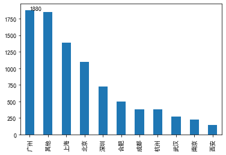

```python
df_plot.city.value_counts().plot(kind='bar')
plt.text(0,df_plot.city.value_counts()[0],df_plot.city.value_counts()[0])
# 核心代码
```

```python
# 构建一个用来返回指定数量随机色彩列表的函数
# matplotlib中，可以使用一个rgb元组（r,g,b）构建色彩，r,g,b的取值范围都在0~1之间
# 利用这个特征，可以构建一个随机的包含3个0~1的元素的元组来生成颜色
def GetColors(n):
    # n是颜色的数量
    Colors = []
    # 构建一个空列表，用来保存颜色
    for i in range(n):
        # 构建一个循环来添加颜色
        RandomColor = tuple(np.random.rand(3))
        # 构建一个随机的颜色元组
        # print(RandomColor)
        Colors.append(RandomColor)
    return Colors
```

```python
GetColors(10)
```

```
[(0.5115172755968354, 0.9163205607278168, 0.9955422808333634),
 (0.142741457496678, 0.21784781223746708, 0.9752271565859532),
 (0.5112447472534938, 0.4589132974098573, 0.6466703813053639),
 (0.08560318228506869, 0.8965606397592637, 0.3870704541834553),
 (0.9655654713692928, 0.42527370983312485, 0.08242683413566099),
 (0.834462378017768, 0.2577296767350469, 0.8140411329459335),
 (0.056028269412870646, 0.5717848349161456, 0.9691215834756509),
 (0.6129016000489038, 0.9780739640369849, 0.22524912040335754),
 (0.43586958632567496, 0.3758957504419941, 0.33085782720866275),
 (0.9594323417920705, 0.5522271834114172, 0.005436793081090019)]
```

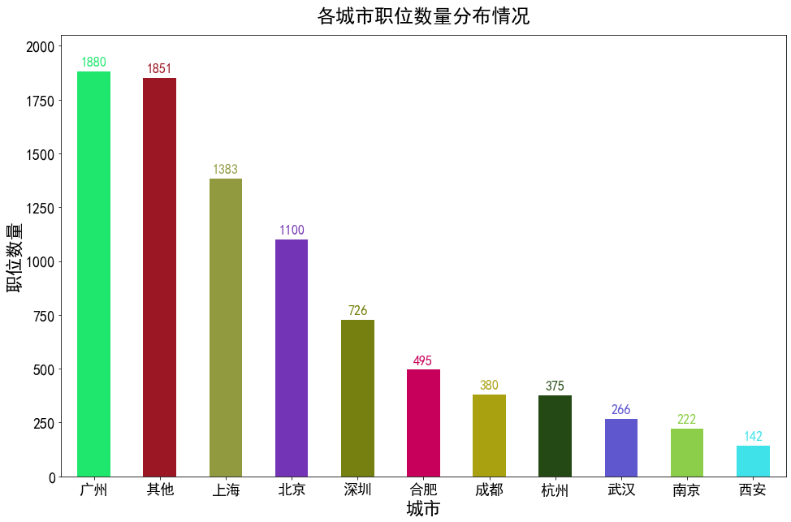

```python
# 城市对职位数量的影响
jobCountCity = df_plot.city.value_counts()
# 获取城市对应的职位数
ColorList = GetColors(jobCountCity.count())
# 获取和城市数量一致的随机颜色列表，保证柱体和数据标签的色彩对应

# 1.绘制基本的柱状图
jobCountCity.plot(kind = 'bar',
                  figsize = (16,10),  # 画布大小
                  rot = 0,            # x轴的ticklabel角度
                  fontsize = 18,      # 字体大小
                  color = ColorList
                  # 颜色，注意颜色的数量可以不和柱体的数量一致，会自动重复
                 )

# 2.绘制数据标签
for i in range(jobCountCity.count()):
    # 遍历Series的索引
    plt.text(i,                       # x轴坐标
             jobCountCity[i] + 25,    # y轴坐标
             jobCountCity[i],         # 文本内容
             fontsize = 16,           # 数据标签的文字大小
             ha = 'center',           # 水平居中对齐
             color = ColorList[i]     # 从色彩列表中调用索引对应的色彩，以保证和柱体颜色一致
            )

# 3.辅助对象
plt.title('各城市职位数量分布情况',fontsize = 24, y = 1.02)    # title
plt.ylim(0,2050)          #  y轴的坐标
plt.xlabel('城市',fontsize = 22)   # x轴的标签
plt.ylabel('职位数量',fontsize = 22)  # y轴的标签

# 4.显示图像，隐藏提示信息
plt.show()
```

通过柱状图可以发现，北上广深四个一线城市提供的职位数占据了一半以上，其中广州最多，深圳最少。不管是招聘还是求职，尽可能考虑一线城市，机会更大

(2)单个因素对职位数量的影响：工作经验

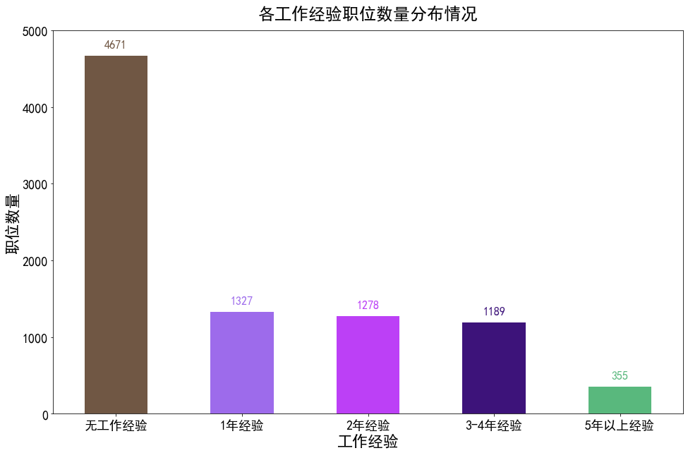

```python
# 工作经验对职位数量的影响
jobCountExp = df_plot.exp.value_counts()
# 获取工作经验对应的职位数
ColorList = GetColors(jobCountExp.count())
# 获取和工作经验数量一致的随机颜色列表，保证柱体和数据标签的色彩对应

# 1.绘制基本的柱状图
jobCountExp.plot(kind = 'bar',
                  figsize = (16,10),  # 画布大小
                  rot = 0,            # x轴的ticklabel角度
                  fontsize = 18,      # 字体大小
                  color = ColorList
                  # 颜色，注意颜色的数量可以不和柱体的数量一致，会自动重复
                 )

# 2.绘制数据标签
for i in range(jobCountExp.count()):
    # 遍历Series的索引
    plt.text(i,                       # x轴坐标
             jobCountExp[i] + 100,    # y轴坐标
             jobCountExp[i],         # 文本内容
             fontsize = 16,           # 数据标签的文字大小
             ha = 'center',           # 水平居中对齐
             color = ColorList[i]     # 从色彩列表中调用索引对应的色彩，以保证和柱体颜色一致
            )

# 3.辅助对象
plt.title('各工作经验职位数量分布情况',fontsize = 24, y = 1.02)    # title
plt.ylim(0,5000)          #  y轴的坐标
plt.xlabel('工作经验',fontsize = 22)   # x轴的标签
plt.ylabel('职位数量',fontsize = 22)  # y轴的标签

# 4.显示图像，隐藏提示信息
plt.show()
```

通过柱状图可以发现，1年经验、2年经验、3-4年经验的职位数量差别不大，但5年以上经验的职位数量急剧下降，说明对5年以上工作经验的人才需求相对较少。另外，有超过一半以上的职位对工作经验没有明确要求，可能需要面谈。

```python
df_plot.head()
```

|  | exp | edu | type | scale | industry | avgsalary | lnsalary | city |
| --- | --- | --- | --- | --- | --- | --- | --- | --- |
| 0 | 5年以上经验 | 本科 | 上市公司 | 1000-5000人 | 互联网/电子商务 | 25.0 | 3.218876 | 上海 |
| 1 | 无工作经验 | 本科 | 外资企业 | 500-1000人 | 其他 | 7.0 | 1.945910 | 上海 |
| 2 | 3-4年经验 | 本科 | 上市公司 | 1000-5000人 | 互联网/电子商务 | 12.5 | 2.525729 | 南京 |
| 3 | 无工作经验 | 大专 | 民营公司 | 50-150人 | 金融/投资/证券 | 7.0 | 1.945910 | 广州 |
| 4 | 1年经验 | 大专 | 外资企业 | 500-1000人 | 金融/投资/证券 | 9.0 | 2.197225 | 广州 |

(3)-(5)学历、公司性质、公司规模对职位数量的影响（最好用函数实现）

(6)单个因素对职位数量的影响：行业类别，用条形图实现

```python
df_plot.industry.value_counts()
```

```
其他                   2169
金融/投资/证券             1831
互联网/电子商务             1776
计算机软件                1237
专业服务(咨询、人力资源、财会)      416
服装/纺织/皮革              368
计算机服务(系统、数据服务、维修)     245
快速消费品(食品、饮料、化妆品)      223
通信/电信运营、增值服务          223
多元化业务集团公司             171
批发/零售                 161
Name: industry, dtype: int64
```

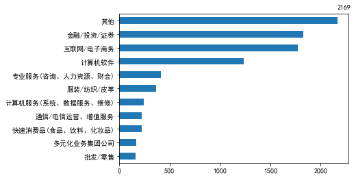

```python
# 核心代码
df_plot.industry.value_counts().sort_values().plot(kind='barh')
# 条形图从原点开始绘制，因此要得到降序的图，数据要改成升序
plt.text(df_plot.industry.value_counts().sort_values()['其他'],    # x轴位置
         len(df_plot.industry.value_counts().sort_values())-1 ,    # y轴的位置
         df_plot.industry.value_counts().sort_values()['其他'],    # 文本
         va = 'center'                                             # 垂直居中对齐
)
```

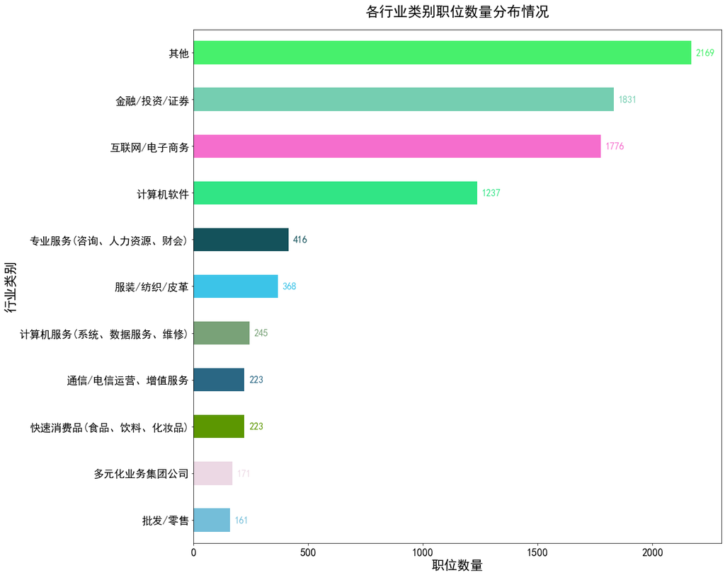

```python
# 行业类别对职位数量的影响
jobCount = df_plot.industry.value_counts().sort_values()
# 获取行业类别对应的职位数，并按升序排列（数据升序图降序）
ColorList = GetColors(jobCount.count())
# 获取和行业类别数量一致的随机颜色列表

# 1.绘制条形图
jobCount.plot(kind = 'barh',
              figsize = (16,16),
              rot = 0,
              fontsize = 18,
              color = ColorList
             )

# 2.绘制数据标签
for i in range(jobCount.count()):
    # 遍历Series的索引
    plt.text(jobCount[i] + 20,   # x轴坐标
             i,                  # y轴坐标
             jobCount[i],        # 文本内容
             fontsize = 16,
             color = ColorList[i],
             va = 'center'
    )

# 3.辅助对象
plt.title('各行业类别职位数量分布情况',fontsize = 24, y = 1.02)    # title
plt.xlim(0,2300)          #  x轴的坐标
plt.xlabel('职位数量',fontsize = 22)   # x轴的标签
plt.ylabel('行业类别',fontsize = 22)  # y轴的标签

# 4.显示图像，隐藏提示信息
plt.show()
```

从条形图可以看出，金融/投资/证券，互联网/电子商务和计算机软件三类行业中集中了对数据分析职位的大部分需求，其他行业的职位需求相对比较少

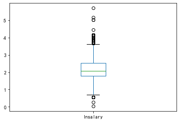

```python
df_plot.lnsalary.plot(kind='box')
```